# Week 2 - Results

Dynamic Tests for Gated and and direct access where incoming packets follow possion arrivals, the theoretical stable throughput values are then correlated with thte observed values.

## Test 1- Gated Acces

The arrival rate is sweeped between 0.2 and 0.7 with a 0.05 step increase. The mean delay is then plotted against the mean arrival rate.

Each simulation run stops after the last tree resolution after 10,000 slots.

### Simple Tree Resolution

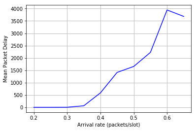

```python
import simstudy
simstudy.simulate_simple_tree_dynamic_multiple_runs_gated(modified=False, unisplit=False, sic=False)
```

### Modified Tree Resolution

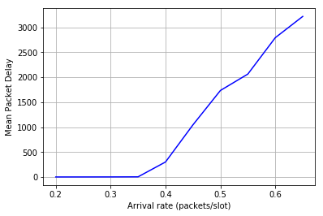

```python
import simstudy
simstudy.simulate_simple_tree_dynamic_multiple_runs_gated(modified=True, unisplit=False, sic=False)
```

### Simple Tree with Uniform Split on the First collision

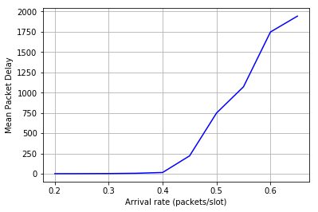

```python
import simstudy
simstudy.simulate_simple_tree_dynamic_multiple_runs_gated(modified=False, unisplit=True, sic=False)
```

### Modified Tree with Uniform Split on First collision

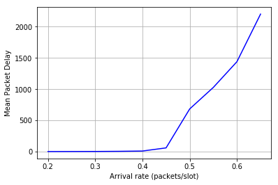

```python
import simstudy
simstudy.simulate_simple_tree_dynamic_multiple_runs_gated(modified=True, unisplit=True, sic=False)
```

## Test 2 - Direct Access

Simply 10,000 Slots are simulated but there is no Queue where the packets are waiting while a tree is being resolved, all incoming packets just transmit immediately and join an ongoing resolution. Since the simulation stops abruptly, all unresolved packets are considered as unseccesful and the mean delay of only the packets that are resolved is plotted, which causes the delay to drop as we get passt the stable throughput. The arrivals at which th delay is maximum is printed.

### Simple Tree

```
Optimum Throughput = 0.35
```

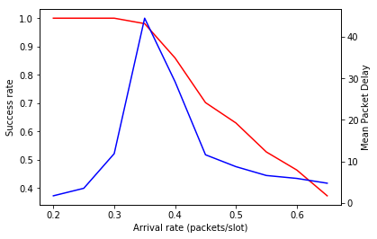

```python
import simstudy
simstudy.simulate_simple_tree_dynamic_multiple_runs(modified=False, unisplit=False, sic=False)
```

### Modified Tree

```
Optimum Throughput = 0.39999999999999997
```

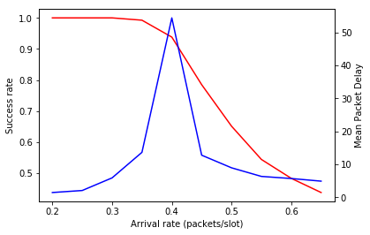

```python
import simstudy
simstudy.simulate_simple_tree_dynamic_multiple_runs(modified=True, unisplit=False, sic=False)
```

### Issues and Future work

The first issue is that SICTA algorithm is still not yeilding the expected result of 0.693 in gated access. This is now the main priority.

The second issue is that the dynamic simulation does not have any Granularity, and if we choose to have higher granularty, it will take a lot of time to simulate. Hence, an efficient way must be thought out. Options are deploying a large code on cloud to solve and give results once the stability is verified or then an optimising algorithm.

Things to be added are Ternary split and also code needs massive cleanup in many places.